# Supplementary Information

Lujun Zhang and Jun Chen

2024-08-12

# 1 Setups and Introduction

## 1.1 Required Packages

- `doParallel`, `foreach`, `doRNG`, `Matrix`, `matrixStats`, `tidyverse`, `data.table`, `peakRAM`, `ggpubr` from CRAN.
- `DESeq2` from Bioconductor.
- `ideas` from https://github.com/Sun-lab/ideas.

## 1.2 Required Dataset

- **File:** “supp_info_anal/n12_12_d1.3_c375_vFALSE_0811_b1.RData”
  - The files “supp_info_anal/mem_results0827.RData,” “supp_info_anal/nperm_results0827.RData,” and “supp_info_anal/time_results0821.RData” are saved cache to accelerate the rendering of the markdown file.
- This dataset was generated in the “Generate Simulation Datasets” step in the “Parametric_simulation.rmd”.
- It contains 12 cases and 12 controls, each with 375 cell replicates.
- The read depths of each cell replicate are well-balanced.
- The dataset comprises a total of 8,000 genes.
- **Signal density:** 15%, with differences in mean, variance, and mean+variance (each at 5%).

## 1.3 Objectives for this file (Supplementary Information)

- Determine the number of permutations required for DiSC.
- Compare the computational time of different methods.
- Evaluate memory usage by DiSC.

```r
library(DESeq2)
library(ideas)
library(tidyverse)
library(matrixStats)
library(knitr)
library(kableExtra)
library(peakRAM)
library(data.table)
library(ggpubr)

knitr::opts_chunk$set(echo = TRUE)
set.seed(seed = 123456)

# rm(list = ls())
file.copy(from = "source_code/DiSC.R", to = "supp_info_anal/DiSC.R",
          copy.date = TRUE, overwrite  = TRUE)
```

```
## [1] TRUE
```

```r
source("supp_info_anal/DiSC.R")
load("supp_info_anal/n12_12_d1.3_c375_vFALSE_0811_b1.RData")
dat_list[["meta_ind"]]$phenotype <- as.factor(dat_list[["meta_ind"]]$phenotype)
dat_list[["meta_cell"]]$phenotype <- as.factor(dat_list[["meta_cell"]]$phenotype)
count_matrix <- dat_list$count_matrix
meta_cell <- dat_list$meta_cell
meta_ind <- dat_list$meta_ind
gene_index <- dat_list$gene_index
```

# 2 Description of the Data Set

```r
str(dat_list)
```

```
## List of 5
##  $ count_matrix   : int [1:8000, 1:9000] 1 0 2 2 0 0 0 1 1 0 ...
##   ..- attr(*, "dimnames")=List of 2
##   .. ..$ : chr [1:8000] "gene1" "gene2" "gene3" "gene4" ...
##   .. ..$ : chr [1:9000] "cell1" "cell2" "cell3" "cell4" ...
##  $ meta_cell      :'data.frame': 9000 obs. of  4 variables:
##   ..$ cell_id   : chr [1:9000] "cell1" "cell2" "cell3" "cell4" ...
##   ..$ individual: chr [1:9000] "ind1" "ind1" "ind1" "ind1" ...
##   ..$ phenotype : Factor w/ 2 levels "0","1": 2 2 2 2 2 2 2 2 2 2 ...
##   ..$ cell_rd   : num [1:9000] 10705 11888 10926 10314 10623 ...
##  $ meta_ind       :'data.frame': 24 obs. of  3 variables:
##   ..$ individual: chr [1:24] "ind1" "ind2" "ind3" "ind4" ...
##   ..$ phenotype : Factor w/ 2 levels "0","1": 2 2 2 2 2 2 2 2 2 2 ...
##   ..$ RIN       : num [1:24] -0.8484 -0.019 0.5216 0.0924 0.523 ...
##  $ gene_index     :List of 4
##   ..$ mean_index    : num [1:400] 3132 234 1066 6001 7294 ...
##   ..$ var_index     : num [1:400] 54 5613 6322 6933 2218 ...
##   ..$ mean_var_index: num [1:400] 7250 167 7588 4605 4324 ...
##   ..$ EE_index      : int [1:6800] 1 2 3 4 5 7 8 10 11 13 ...
##  $ random_idx_gene: int [1:8000] 1323 236 2395 6592 839 4310 5023 2234 7782 4832 ...
```

```r
ngene = nrow(count_matrix)
ngene
```

```
## [1] 8000
```

```r
nsamp = ncol(count_matrix)
nsamp
```

```
## [1] 9000
```

```r
colSums(count_matrix)[1:10]
```

```
##  cell1  cell2  cell3  cell4  cell5  cell6  cell7  cell8  cell9 cell10
##  10705  11888  10926  10314  10623  10075  10439  10850  11346  10639
```

```r
meta_cell$cell_rd[1:10]
```

```
##  [1] 10705 11888 10926 10314 10623 10075 10439 10850 11346 10639
```

```r
table(meta_cell$individual)
```

```
##
##  ind1 ind10 ind11 ind12 ind13 ind14 ind15 ind16 ind17 ind18 ind19  ind2 ind20
##   375   375   375   375   375   375   375   375   375   375   375   375   375
## ind21 ind22 ind23 ind24  ind3  ind4  ind5  ind6  ind7  ind8  ind9
##   375   375   375   375   375   375   375   375   375   375   375
```

```r
table(meta_ind$phenotype)
```

```
##
##  0  1
## 12 12
```

```r
sparsity = rowSums(count_matrix == 0)/ngene
summary(sparsity)
```

```
##     Min.  1st Qu.   Median     Mean  3rd Qu.     Max.
## 0.000125 0.468469 0.693562 0.620265 0.828531 0.989375
```

# 3 Number of permutations

If adjusted p-values (FDR) are of primary interest, which is usually the case, setting `perm.no` = 99 will suffice and can accelarate the calculations while reducing memory usage.

```r
set.seed(seed = 123456)
fp <- "supp_info_anal/nperm_results0827.RData"
if(file.exists(fp)){
  load(fp)
} else {
  # default
  obj1 <- DiSC(data.mat = count_matrix,
               cell.ind = meta_cell,
               metadata = meta_ind,
               outcome = "phenotype", covariates = "RIN",
               cell.id = "cell_id",
               individual.id = "individual",
               perm.no = 999, verbose = FALSE, sequencing.data = TRUE)

  obj2 <- DiSC(data.mat = count_matrix,
               cell.ind = meta_cell,
               metadata = meta_ind,
               outcome = "phenotype", covariates = "RIN",
               cell.id = "cell_id",
               individual.id = "individual",
               perm.no = 499, verbose = FALSE, sequencing.data = TRUE)

  #for fdr calculation
  obj3 <- DiSC(data.mat = count_matrix,
               cell.ind = meta_cell,
               metadata = meta_ind,
               outcome = "phenotype", covariates = "RIN",
               cell.id = "cell_id",
               individual.id = "individual",
               perm.no = 99, verbose = FALSE, sequencing.data = TRUE)

  obj4 <- DiSC(data.mat = count_matrix,
               cell.ind = meta_cell,
               metadata = meta_ind,
               outcome = "phenotype", covariates = "RIN",
               cell.id = "cell_id",
               individual.id = "individual",
               perm.no = 49, verbose = FALSE, sequencing.data = TRUE)
  save(obj1, obj2, obj3, obj4, file = fp)
}


gene_stra <- unlist(gene_index) %>%
  sort() %>% names() %>% str_extract(pattern = "\\w+_index")
gene_stra[gene_index$mean_index[1:10]] # mean_index
```

[1] “mean_index” “mean_index” “mean_index” “mean_index” “mean_index” [6] “mean_index” “mean_index” “mean_index” “mean_index” “mean_index”

```r
meths = c("p.raw", "p.adj.fdr")

for(me in meths){
  p_cat <- cut(obj1[[me]],
               breaks = c(-1, 0.001, 0.01, 0.05, 0.10, +Inf),
               labels = c("<= 0.001", "0.001 - 0.01",
                          "0.01 - 0.05", "0.05 - 0.10",
                          "> 0.10"))
  N_perm_results <-
    tibble("P value category" = p_cat, "Gene stratum" = gene_stra,
           "N.perm = 999" = obj1[[me]], "N.perm = 499" = obj2[[me]],
           "N.perm = 99" = obj3[[me]],  "N.perm = 49" = obj4[[me]])
  flag <- str_remove(str_extract(me, "\\.\\w+$"), "\\.")
  N_perm_results %>% group_by(`P value category`, `Gene stratum`) %>%
    slice_head(n = 1) %>%
    kbl(digits = 4,
        caption = str_glue("Influence of the number of permutations in P values ({flag})")) %>%
    kable_classic(full_width = F, html_font = "Cambria") %>%
    print()
  N_perm_table <- N_perm_results %>% select(-`Gene stratum`) %>%
    group_by(`P value category`) %>%
    slice_head(n = 1) %>%
    kbl(digits = 4,
        caption = str_glue("Influence of the number of permutations in P values ({flag})")) %>%
    kable_classic(full_width = F, html_font = "Cambria")
  save_kable(N_perm_table, file = str_glue("results/N_perm_{flag}.jpeg"),
             density = 1000, zoom = 2.5)
  print(N_perm_table)
}
```

Influence of the number of permutations in P values (raw)

| P value category | Gene stratum | N.perm = 999 | N.perm = 499 | N.perm = 99 | N.perm = 49 |
| --- | --- | --- | --- | --- | --- |
| <= 0.001 | EE_index | 0.001 | 0.004 | 0.01 | 0.02 |
| <= 0.001 | mean_index | 0.001 | 0.002 | 0.01 | 0.02 |
| <= 0.001 | mean_var_index | 0.001 | 0.002 | 0.01 | 0.02 |
| <= 0.001 | var_index | 0.001 | 0.004 | 0.01 | 0.02 |
| 0.001 - 0.01 | EE_index | 0.006 | 0.004 | 0.01 | 0.02 |
| 0.001 - 0.01 | mean_index | 0.006 | 0.016 | 0.03 | 0.02 |
| 0.001 - 0.01 | mean_var_index | 0.002 | 0.004 | 0.01 | 0.02 |
| 0.001 - 0.01 | var_index | 0.007 | 0.004 | 0.01 | 0.02 |
| 0.01 - 0.05 | EE_index | 0.013 | 0.028 | 0.03 | 0.04 |
| 0.01 - 0.05 | mean_index | 0.015 | 0.016 | 0.02 | 0.04 |
| 0.01 - 0.05 | mean_var_index | 0.025 | 0.032 | 0.04 | 0.06 |
| 0.01 - 0.05 | var_index | 0.019 | 0.020 | 0.04 | 0.02 |
| 0.05 - 0.10 | EE_index | 0.072 | 0.086 | 0.07 | 0.12 |
| 0.05 - 0.10 | mean_index | 0.058 | 0.046 | 0.04 | 0.10 |
| 0.05 - 0.10 | mean_var_index | 0.092 | 0.074 | 0.11 | 0.12 |
| 0.05 - 0.10 | var_index | 0.065 | 0.106 | 0.11 | 0.04 |
| > 0.10 | EE_index | 0.606 | 0.586 | 0.55 | 0.72 |
| > 0.10 | mean_index | 0.546 | 0.536 | 0.55 | 0.66 |
| > 0.10 | mean_var_index | 0.140 | 0.156 | 0.16 | 0.16 |
| > 0.10 | var_index | 0.420 | 0.460 | 0.48 | 0.50 |

Influence of the number of permutations in P values (raw)

| P value category | N.perm = 999 | N.perm = 499 | N.perm = 99 | N.perm = 49 |
| --- | --- | --- | --- | --- |
| <= 0.001 | 0.001 | 0.004 | 0.01 | 0.02 |
| 0.001 - 0.01 | 0.007 | 0.004 | 0.01 | 0.02 |
| 0.01 - 0.05 | 0.013 | 0.028 | 0.03 | 0.04 |
| 0.05 - 0.10 | 0.072 | 0.086 | 0.07 | 0.12 |
| > 0.10 | 0.606 | 0.586 | 0.55 | 0.72 |

Influence of the number of permutations in P values (fdr)

| P value category | Gene stratum | N.perm = 999 | N.perm = 499 | N.perm = 99 | N.perm = 49 |
| --- | --- | --- | --- | --- | --- |
| <= 0.001 | mean_index | 0.0001 | 0.0003 | 0.0002 | 0.0001 |
| <= 0.001 | mean_var_index | 0.0000 | 0.0000 | 0.0001 | 0.0001 |
| <= 0.001 | var_index | 0.0006 | 0.0007 | 0.0011 | 0.0005 |
| 0.001 - 0.01 | EE_index | 0.0086 | 0.0089 | 0.0087 | 0.0085 |
| 0.001 - 0.01 | mean_index | 0.0078 | 0.0082 | 0.0080 | 0.0079 |
| 0.001 - 0.01 | mean_var_index | 0.0024 | 0.0028 | 0.0028 | 0.0026 |
| 0.001 - 0.01 | var_index | 0.0024 | 0.0027 | 0.0028 | 0.0026 |
| 0.01 - 0.05 | EE_index | 0.0305 | 0.0313 | 0.0298 | 0.0297 |
| 0.01 - 0.05 | mean_index | 0.0106 | 0.0109 | 0.0103 | 0.0100 |
| 0.01 - 0.05 | mean_var_index | 0.0125 | 0.0127 | 0.0122 | 0.0118 |
| 0.01 - 0.05 | var_index | 0.0480 | 0.0492 | 0.0472 | 0.0469 |
| 0.05 - 0.10 | EE_index | 0.0507 | 0.0517 | 0.0496 | 0.0499 |
| 0.05 - 0.10 | mean_index | 0.0883 | 0.0896 | 0.0857 | 0.0884 |
| 0.05 - 0.10 | mean_var_index | 0.0573 | 0.0586 | 0.0562 | 0.0566 |
| 0.05 - 0.10 | var_index | 0.0967 | 0.0984 | 0.0945 | 0.0971 |
| > 0.10 | EE_index | 0.8914 | 0.8922 | 0.8880 | 0.8891 |
| > 0.10 | mean_index | 0.9312 | 0.9317 | 0.9283 | 0.9297 |
| > 0.10 | mean_var_index | 0.6238 | 0.6270 | 0.6162 | 0.6195 |
| > 0.10 | var_index | 0.1079 | 0.1095 | 0.1051 | 0.1078 |

Influence of the number of permutations in P values (fdr)

| P value category | N.perm = 999 | N.perm = 499 | N.perm = 99 | N.perm = 49 |
| --- | --- | --- | --- | --- |
| <= 0.001 | 0.0000 | 0.0000 | 0.0001 | 0.0001 |
| 0.001 - 0.01 | 0.0024 | 0.0027 | 0.0028 | 0.0026 |
| 0.01 - 0.05 | 0.0480 | 0.0492 | 0.0472 | 0.0469 |
| 0.05 - 0.10 | 0.0883 | 0.0896 | 0.0857 | 0.0884 |
| > 0.10 | 0.8914 | 0.8922 | 0.8880 | 0.8891 |

# 4 Computational time

- Examining computational time over three factors:
  - By the number of genes
  - By the number of cells
  - By the number of samples/individuals

## 4.1 Calculations

```r
set.seed(seed = 123456)
fp <- "supp_info_anal/time_results0821.RData"
if(file.exists(fp))
  load(fp) else
  {
    setups <- function(dat_list, ngene = 700, ncell = 100, nsample = 5){
      count_matrix <- dat_list$count_matrix
      gene_index <- dat_list$gene_index
      meta_ind <- dat_list$meta_ind
      meta_cell <- dat_list$meta_cell

      count_matrix <- count_matrix[1:ngene,]
      gene_index <- lapply(gene_index, function(gs) gs[gs <= ngene])
      meta_cell$cell_rd <- colSums(count_matrix)

      meta_cell <- meta_cell %>% group_by(individual) %>% slice_head(n=ncell)
      count_matrix <- count_matrix[, meta_cell$cell_id]

      meta_ind <- meta_ind %>% group_by(phenotype) %>% slice_head(n=nsample)
      meta_cell <- meta_cell %>% filter(individual %in% meta_ind$individual)
      count_matrix <- count_matrix[, meta_cell$cell_id]

      return(list(count_matrix = count_matrix, gene_index = gene_index,
                  meta_ind = meta_ind, meta_cell = meta_cell))
    }
    ideas_wrapper <- function(dat_list_temp){
      with(dat_list_temp, suppressMessages({
        dist1 <- suppressWarnings(
          ideas_dist(count_input = count_matrix,
                     meta_cell = meta_cell, meta_ind = meta_ind,
                     var_per_cell = "cell_rd", var2test = "phenotype",
                     var2test_type = "binary",
                     d_metric = "Was", fit_method = "nb")
        )
        ideas_pval_raw <- permanova(dist_array = dist1, meta_ind = meta_ind,
                                    var2test = "phenotype", var2adjust = "RIN",
                                    var2test_type = "binary", n_perm=999)
      }))
    }

    disc_wrapper <- function(dat_list_temp){
      with(dat_list_temp, suppressMessages({
        # default
        obj1 <- DiSC(data.mat = count_matrix,
                     cell.ind = meta_cell,
                     metadata = meta_ind,
                     outcome = "phenotype", covariates = "RIN",
                     cell.id = "cell_id",
                     individual.id = "individual",
                     perm.no = 999, verbose = FALSE, sequencing.data = TRUE)
      }))
    }

    deseq_wrapper<- function(dat_list_temp){
      with(dat_list_temp, suppressMessages({
        # prepossing
        count_matrix_bulk = matrix(NA, nrow = nrow(count_matrix),
                                   ncol = nrow(meta_ind))
        rownames(count_matrix_bulk) = rownames(count_matrix)
        colnames(count_matrix_bulk) = meta_ind[["individual"]]
        if(sum(meta_cell[["cell_id"]] != colnames(count_matrix))==0)
          for (i_ind in 1:length(meta_ind[["individual"]])) {
            cur_ind   = meta_ind[["individual"]][i_ind]
            cur_ind_m = count_matrix[, meta_cell[["individual"]] == cur_ind]
            count_matrix_bulk[, i_ind] = rowSums(cur_ind_m, na.rm = TRUE)
          }else
            stop("meta_cell$cell_id and colnames(count_matrix) dont match")

        dds <- DESeq2::DESeqDataSetFromMatrix(countData = count_matrix_bulk,
                                              colData = meta_ind,
                                              design = ~ RIN + phenotype)
        dds <- DESeq2::DESeq(dds, quiet = TRUE)
        deseq_pval_adj <- DESeq2::results(dds, name = "phenotype_1_vs_0",
                                          independentFiltering=FALSE,
                                          cooksCutoff=FALSE)$padj
        deseq_pval_raw <- DESeq2::results(dds, name = "phenotype_1_vs_0",
                                          independentFiltering=FALSE,
                                          cooksCutoff=FALSE)$pvalue
      }))
    }

    boot = 5
    results <- data.frame(expr = character(), time = numeric(),
                          ngene = numeric(), ncell = numeric(),
                          nsample = numeric())
    NGENES <- c(700, 800, 900, 1000)
    NCELL <- c(100, 150, 200, 250)
    NSAMPLE <- c(5, 6, 7, 8)
    parameters <- bind_rows(
      data.frame(nc = NCELL[1], ns = NSAMPLE[1], ng = NGENES),
      data.frame(nc = NCELL[1], ns = NSAMPLE, ng = NGENES[1]),
      data.frame(nc = NCELL, ns = NSAMPLE[1], ng = NGENES[1])
    ) %>% distinct(.keep_all = TRUE)


    for(pa in 1:nrow(parameters)){
      nc = parameters[pa, "nc"]
      ns = parameters[pa, "ns"]
      ng = parameters[pa, "ng"]
      dat_list_temp <- setups(dat_list, ngene = ng, ncell = nc, nsample = ns)
      res <- microbenchmark::microbenchmark(disc_wrapper(dat_list_temp),
                                            ideas_wrapper(dat_list_temp),
                                            deseq_wrapper(dat_list_temp),
                                            times = boot)
      res$ngene = rep(ng, length = boot*3)
      res$ncell = rep(nc, length = boot*3)
      res$nsample = rep(ns, length = boot*3)
      results <- bind_rows(results, as.data.frame(res))
      # run the disc and deseq a few more times to get more accurate estimates
      res <- microbenchmark::microbenchmark(disc_wrapper(dat_list_temp),
                                            deseq_wrapper(dat_list_temp),
                                            times = boot*9)
      res$ngene = rep(ng, length = boot*2*9)
      res$ncell = rep(nc, length = boot*2*9)
      res$nsample = rep(ns, length = boot*2*9)
      results <- bind_rows(results, as.data.frame(res))
    }

    #canonical case with ~8000 genes and ~24 samples
    dat_list_temp <- setups(dat_list, ngene = 8000,
                            ncell = 30, nsample = 3)
    res_c <- microbenchmark::microbenchmark(
      disc_wrapper(dat_list), #8,000 genes, 24 individuals, and 9,000 cells
      disc_wrapper(dat_list_temp), #8,000 genes, 6 individuals, and 180 cells
      times = 5)

    save(results, res_c,
         parameters, setups,
         disc_wrapper, ideas_wrapper, deseq_wrapper,
         NGENES, NCELL, NSAMPLE,
         file = fp)
  }
```

## 4.2 Results

```r
#canonical case with 8000 genes and 24 samples
res_c$time <- res_c$time/1e9
cat("Analyzing DE genes in a typical scRNA-seq dataset with 8,000 genes, 24 individuals, and 9,000 cells (375 per individual) using DiSC took",
    round(mean(res_c$time[res_c$expr == "disc_wrapper(dat_list)"]), 2),
    "seconds") #canonical case with 8000 genes and 24 samples, in seconds
```

```
## Analyzing DE genes in a typical scRNA-seq dataset with 8,000 genes, 24 individuals, and 9,000 cells (375 per individual) using DiSC took 29.37 seconds
```

```r
cat("Analyzing DE genes in a scRNA-seq dataset with 8,000 genes, 6 individuals, and 180 cells (30 per individual) using DiSC took",
    round(mean(res_c$time[res_c$expr == "disc_wrapper(dat_list_temp)"]), 2),
    "seconds, which is predicted to be",
    round(predict(lm(data = results, formula = time/1e9~ngene,
               subset = (expr == "disc_wrapper(dat_list_temp)" &
                           ncell == NCELL[1] & nsample == NSAMPLE[1])),
            newdata = data.frame(ngene = 8000)), 2)
) #canonical case with 8000 genes and 24 samples, in seconds
```

```
## Analyzing DE genes in a scRNA-seq dataset with 8,000 genes, 6 individuals, and 180 cells (30 per individual) using DiSC took 21.93 seconds, which is predicted to be 20.59
```

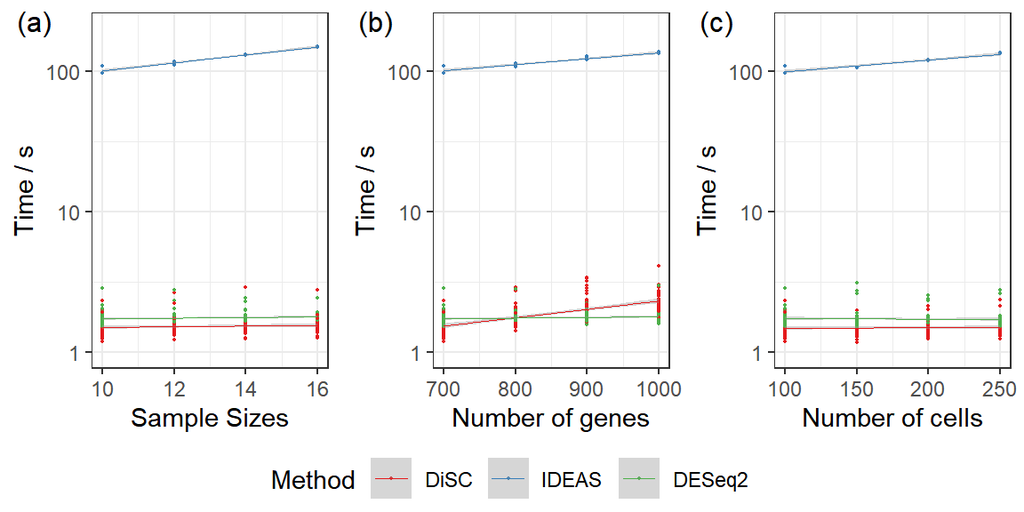

```r
meths = c("DiSC", "IDEAS", "DESeq2")
results <- results %>%
  mutate(time = time/1e9) %>%
  dplyr::rename(method = "expr") %>%
  mutate(method = fct_recode(method, DiSC = "disc_wrapper(dat_list_temp)",
                             DESeq2 = "deseq_wrapper(dat_list_temp)",
                             IDEAS = "ideas_wrapper(dat_list_temp)")) %>%
  mutate(method = fct_relevel(method, meths))

fig1 <- results %>%
  filter(ngene == NGENES[1], ncell == NCELL[1]) %>%
  ggplot(aes(x = nsample*2, y= time, color = method)) + # nsample *2 for two arms
  geom_point(size=0.3) +
  geom_smooth(method = "lm", formula = y ~ x, se = TRUE, linewidth = 0.3) +
  xlab("Sample Sizes") + ylab("Time / s") +
  scale_y_log10(limits = c(1, 200)) +
  scale_color_brewer(palette = "Set1", name = "Method") +
  theme_bw()
fig2 <- results %>%
  filter(nsample == NSAMPLE[1], ncell == NCELL[1]) %>%
  ggplot(aes(x = ngene, y= time, color = method)) +
  geom_point(size=0.3) +
  geom_smooth(method = "lm", formula = y ~ x, se = TRUE, linewidth = 0.3) +
  xlab("Number of genes") + ylab("Time / s") +
  scale_y_log10(limits = c(1, 200)) +
  scale_color_brewer(palette = "Set1", name = "Method") +
  theme_bw()
fig3 <- results %>%
  filter(nsample == NSAMPLE[1], ngene == NGENES[1]) %>%
  ggplot(aes(x = ncell, y= time, color = method)) +
  geom_point(size=0.3) +
  geom_smooth(method = "lm", formula = y ~ x, se = TRUE, linewidth = 0.3) +
  xlab("Number of cells") + ylab("Time / s") +
  scale_y_log10(limits = c(1, 200)) +
  scale_color_brewer(palette = "Set1", name = "Method") +
  theme_bw()

time_fig <-
  ggarrange(fig1, fig2, fig3, ncol = 3, labels = c("(a)", "(b)", "(c)"),
            legend = "bottom", common.legend = TRUE,
            font.label = list(size = 12, color = "black",
                              face = "plain", family = NULL))
time_fig
```

```r
ggsave(filename = "results/comp_time.jpeg", time_fig,
       width = 6, height = 3)
ggsave(filename = "results/comp_time.pdf", time_fig,
       width = 6, height = 3)
```

## 4.3 Memory usage

- Peak memory usage may vary between runs due to autonomous garbage collection in R.

```r
set.seed(seed = 123456)
#default
fp <- "supp_info_anal/mem_results0827.RData"
if(file.exists(fp))
{
  load(fp)
} else {
  gc()
  gc()
  mem_df <- peakRAM({
    # default
    obj1 <- DiSC(data.mat = count_matrix,
                 cell.ind = meta_cell,
                 metadata = meta_ind,
                 outcome = "phenotype", covariates = "RIN",
                 cell.id = "cell_id",
                 individual.id = "individual",
                 perm.no = 999, verbose = FALSE, sequencing.data = TRUE)
  }, {
    # for FDR calculation
    obj3 <- DiSC(data.mat = count_matrix,
                 cell.ind = meta_cell,
                 metadata = meta_ind,
                 outcome = "phenotype", covariates = "RIN",
                 cell.id = "cell_id",
                 individual.id = "individual",
                 perm.no = 99, verbose = FALSE, sequencing.data = TRUE)
  })
  save(mem_df, file = fp)
}


mem_df$Function_Call <- c("N.perm = 999" , "N.perm = 99")
mem_df %>%
  kbl(digits = 5,
      caption = str_glue("Peak momory usage")) %>%
  kable_classic(full_width = F, html_font = "Cambria") %>%
  print()
```

Peak momory usage

| Function_Call | Elapsed_Time_sec | Total_RAM_Used_MiB | Peak_RAM_Used_MiB |
| --- | --- | --- | --- |
| N.perm = 999 | 31.34 | 0.0 | 2719.3 |
| N.perm = 99 | 11.12 | 0.1 | 1495.1 |